# hw10

There are 10 soldiers in a small barracks. For each soldier there is a probability of 0.02 (2%) of contracting a variant of Covid-19 (independently from each other). The doctor wants to determine whether any of them have that Covid-19 variant. Since the tests are hard to come by, the doctor mixes together blood samples from all the 10 soldiers and performs a test on the mixed blood. If any one of the soldiers has Covid-19 variant the mixed blood will test positive.

(a) What is the probability the mixed blood will test positive?

let P(s) represent the probability that a soldier tests positive let P(a) represent the probability that the mixed solution tests positive

(b) John is one of the soldier among the ten. What is the probability that John has the disease if the mixed blood test is positive?

let P(j) represent the probability that john tests positive

P(j | a) = P(a | j) * P(j) / P(a) P(a | j) = 1 P(j) = 0.02 P(a) = 0.182927193

P(j | a) = 0.109333116

(c) If the mixed blood is positive, the doctor will test individually all the ten soldiers. What is the expected total number of Covid-19 tests that the doctor has to perform?

E(tests) = 1 * 0.8171 + 11 * 0.1829

E(tests) = 0.8171 + 2.0119 = 2.829

So the doctor is expected to perform about **2.83 tests**.

A call center company is interested in modeling the number of calls that they receive in a 10 minute interval in order to determine how many operators to hire. The list[int] `call_center_data` contains the some data they collected in the month of October on the number of calls received in 10 minute intervals.

```python
call_center_data = [4,9,8,10,11,11,14,10,5,15,10,7,7,10,9,6,6,4,5,10,7,3,2,1,6,8,13,15,9,14,10,10,9,11,9,12,8,10,8,15,9,11,9,11,4,5,2,2,10,5,8,8,13,11,10,17,14,10,16,11,9,9,11,9,7,11,4,7,6,6,4,3,12,10,12,8,9,9,9,9,12,10,7,11,11,5,4,9,9,11,5,8,7,3,1,3,17,21,14,11,13,16,8,15,6,19,12,10,14,12,16,9,6,8,8,2,7,11,6,5,9,14,6,11,9,8,14,7,10,12,15,12,9,4,13,9,6,9,7,6,10,8,4,6,8,11,13,10,13,15,10,12,12,14,8,16,12,10,8,5,9,10,5,6,7,1,8,3,8,6,10,5,4,11,7,7,5,7,12,7,14,14,11,10,4,10,7,9,7,2,4,4,1,0,1,4,8,3,12,8,9,9,7,9,7,7,7,10,9,11,4,4,7,4,4,3,7,9,9,13,10,15,13,13,11,11,13,12,8,12,13,5,6,13,14,9,5,7,7,7,8,13,7,9,9,5,5,16,6,11,11,10,11,9,6,6,10,11,7,5,10,8,6,1,10,8,3,8,6,6,10,5,2,5,3,2,8,10,10,3,2,10,4,7,4,4,12,7,5,7,6,6,1,8,3,2,7,6,7,9,6,5,5,6,4,2,1,6,3,4,5,1,2,7,7,4,8,7,7,9,9,6,10,9,8,8,6,4,2,7,6,2,4,3,5,3,4,2,10,12,4,7,5,4,7,8,7,6,9,5,3,5,4,5,5,4,5,4,7,6,5,8,4,3,8,8,6,4,5,7,2,5,1,3,3,5,3,7,5,2,3,2,2,1,13,16,9,17,10,12,11,18,18,17,12,14,9,13,11,7,9,5,9,11,3,4,4,5,7,12,7,8,12,9,6,10,13,15,9,10,8,8,14,15,6,15,6,10,11,2,3,0]
```

(a) Let X be the number of calls that arrive at the call center in a 10 minute interval. Find the observed probability (relative frequency) distribution of X from the data collected in October.

```python
from collections import Counter


observed_distribution = {
    k: v / len(call_center_data) for k, v in sorted(Counter(call_center_data).items())
}
observed_distribution
```

```
{0: 0.004629629629629629,
 1: 0.02546296296296296,
 2: 0.04398148148148148,
 3: 0.05092592592592592,
 4: 0.08101851851851852,
 5: 0.08333333333333333,
 6: 0.08333333333333333,
 7: 0.1087962962962963,
 8: 0.08564814814814815,
 9: 0.10416666666666667,
 10: 0.09027777777777778,
 11: 0.06712962962962964,
 12: 0.04861111111111111,
 13: 0.037037037037037035,
 14: 0.03009259259259259,
 15: 0.023148148148148147,
 16: 0.013888888888888888,
 17: 0.009259259259259259,
 18: 0.004629629629629629,
 19: 0.0023148148148148147,
 21: 0.0023148148148148147}
```

(b) Calculate the average number λ of calls received per 10 minute interval in October

```python
from statistics import mean


mean(call_center_data)
```

```
7.921296296296297
```

(c) Randomly occurring telephone calls are often modeled by a Poisson distribution. Calculate the theoretical probability distribution of X assuming a Poisson distribution with mean λ that you calculated in part (b).

```python
from scipy.stats import poisson


poisson_distribution = {
    k: poisson.pmf(k, mu=mean(call_center_data)) for k in observed_distribution
}
poisson_distribution
```

```
{0: np.float64(0.0003629315546010011),
 1: np.float64(0.0028748883792699687),
 2: np.float64(0.011386421335488226),
 3: np.float64(0.0300650723842907),
 4: np.float64(0.059538586631390465),
 5: np.float64(0.09432455715398985),
 6: np.float64(0.12452879420561482),
 7: np.float64(0.14091849661759712),
 8: np.float64(0.13953214566707667),
 9: np.float64(0.12280838540965473),
 10: np.float64(0.0972801608499623),
 11: np.float64(0.0700531798039923),
 12: np.float64(0.04624266614376205),
 13: np.float64(0.028177066158111375),
 14: np.float64(0.015942777842767344),
 15: np.float64(0.008419164471905818),
 16: np.float64(0.004168168521826062),
 17: np.float64(0.0019421939926046862),
 18: np.float64(0.0008547052266838046),
 19: np.float64(0.00035633543929239255),
 21: np.float64(5.3235611077057785e-05)}
```

(d) Plot the two probability distributions (a) and (c) together on the same plot. Looking at the plot, decide whether our assumption that X follows a Poisson distribution is reasonable or not.

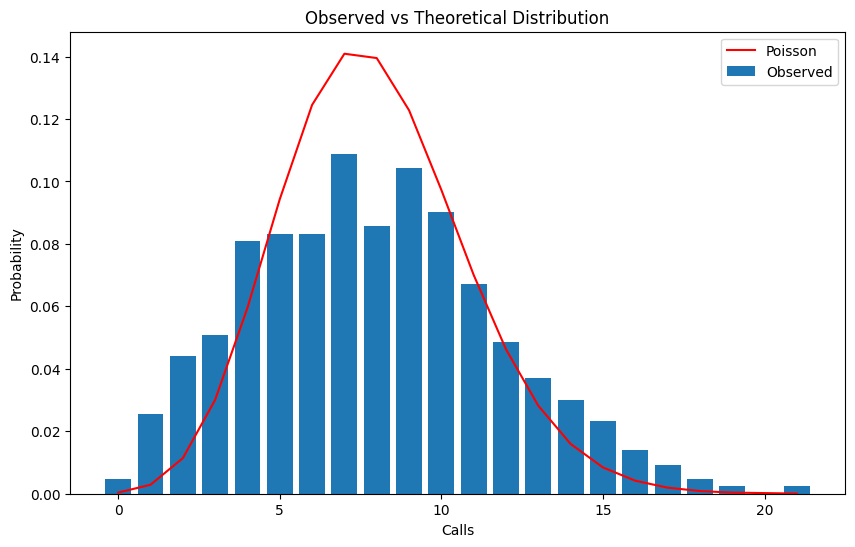

```python
import matplotlib.pyplot as plt

# Convert to lists for plotting
observed_probs = [observed_distribution[i] for i in observed_distribution]
poisson_probs = [poisson_distribution[i] for i in observed_distribution]

plt.figure(figsize=(10, 6))
plt.bar(
    observed_distribution.keys(),
    observed_distribution.values(),
    label="Observed",
    align="center",
)
plt.plot(
    observed_distribution.keys(),
    poisson_distribution.values(),
    label="Poisson",
    color="red",
)
plt.xlabel("Calls")
plt.ylabel("Probability")
plt.title("Observed vs Theoretical Distribution")
plt.legend()
plt.show()
```